# 1. Import drug screen data

gDR team

[gDR team](https://github.com/gdrplatform)

2026-06-01

[figure not shown]

1. Import drug screen data

**gDR Analysis Pipeline**

Date: 2026-06-01

Author: [gDR team](https://github.com/gdrplatform)

# 1 Introduction

This report covers the first step in the gDR analysis pipeline: importing raw data, adding descriptive metadata, and performing initial quality control (QC). The goal is to produce a clean, organized dataset that is ready for reliable dose-response analysis.

```r
library(qs2)
library(purrr)
library(data.table)
library(summarytools)
library(gDRutils)
library(gDRimport)
library(gDRcore)
library(gDR)
library(gDRplots)
```

```r
# get working directory path
wd <- "here::here()"
```

# 2 Key Output Files

This report generates several key files that are used in the subsequent steps of the gDR pipeline.

## 2.1 Data Annotation Files (in `data_annotation/` folder):

- **`drug_annotation.csv`:** An annotation file listing all unique drugs found in the data with their annotations.
- **`cell_line_annotation.csv`:** An annotation file listing all unique cell lines found in the data with their annotations.

## 2.2 Processed gDR Data (in `gDR_data/` folder):

- **`gDR_input.qs2`:** This is the primary output of Step 1. It is a single, cleaned, and annotated `data.table` in a ‘tidy’ format, ready to be used as the input for the ‘Step 2: Data Processing’ report.

# 3 Import Raw Data into gDR and Do Manual Cleanup

This step merges experimental information from three sources: the manifest (plate metadata), template files (well layouts), and raw data files (instrument readouts). This produces the initial raw dataset for the gDR pipeline.

## 3.1 Minimum Required Fields

For single-agent data, the following fields are essential for the gDR pipeline input:

- **Gnumber**: Unique identifier for the experiment.
- **clid**: Cell line identifier.
- **ReadoutValue**: Measurement value obtained.
- **Duration**: Duration of the experiment.

## 3.2 Additional Annotations

In addition to the minimum required fields, the data undergoes a transformation process where annotations are added. These annotations enhance the contextual understanding of the data and include:

- **For Cell Lines**: Information such as cell line name, primary tissue, doubling time, parental identifier, and subtype.
- **For Drugs**: Details about the drug, including its name and mechanism of action.

## 3.3 Annotation Guidelines

The process for annotating the data adheres to the guidelines specified in the gDR annotation documentation. Detailed guidelines and instructions can be found in the [gDR Annotation Documentation](https://github.com/gdrplatform/gDRcore/blob/main/vignettes/gDR-annotation.Rmd).

```r
#import data
manifest <- c(
  "raw_data/Project41.Belva.S01.manifest.xlsx"
)
treatment <- c(
  "raw_data/P41.Belva.mtx17.template.xlsx"
)
raw_data <- c(
  "raw_data/E63903mtx17.csv",
  "raw_data/E68903mtx17.csv",
  "raw_data/E73903mtx17.csv",
  "raw_data/E74908mtx17.csv",
  "raw_data/E75908mtx17.csv",
  "raw_data/E76908mtx17.csv",
  "raw_data/E77903mtx17.csv",
  "raw_data/E78903mtx17.csv",
  "raw_data/E79903mtx17.csv",
  "raw_data/E80903mtx17.csv",
  "raw_data/E81903mtx17.csv",
  "raw_data/E82903mtx17.csv",
  "raw_data/E83903mtx17.csv",
  "raw_data/E84903mtx17.csv",
  "raw_data/E85903mtx17.csv",
  "raw_data/E86903mtx17.csv",
  "raw_data/E87903mtx17.csv",
  "raw_data/E88908mtx17.csv",
  "raw_data/E90915mtx17.csv",
  "raw_data/E91908mtx17.csv",
  "raw_data/E92915mtx17.csv",
  "raw_data/E93915mtx17.csv",
  "raw_data/E95908mtx17.csv",
  "raw_data/E97908mtx17.csv",
  "raw_data/E98908mtx17.csv",
  "raw_data/H01908mtx17.csv",
  "raw_data/H02908mtx17.csv",
  "raw_data/H03915mtx17.csv",
  "raw_data/H04908mtx17.csv",
  "raw_data/H09915mtx17.csv",
  "raw_data/H16908mtx17.csv",
  "raw_data/H19908mtx17.csv",
  "raw_data/H23908mtx17.csv",
  "raw_data/H24908mtx17.csv",
  "raw_data/H26908mtx17.csv",
  "raw_data/K03915mtx17.csv",
  "raw_data/K05908mtx17.csv",
  "raw_data/K06908mtx17.csv",
  "raw_data/K07917mtx17.csv",
  "raw_data/K11915mtx17.csv",
  "raw_data/K12908mtx17.csv",
  "raw_data/K14915mtx17.csv",
  "raw_data/K16915mtx17.csv"
)

# copy files to raw_data
for (file_path in c(manifest, treatment, raw_data)) {
  file_name <- basename(file_path)  # Extract the filename from the path
  file.copy(file_path, file.path(wd, "raw_data", file_name))
}

data_imported <- import_data(manifest,
                             treatment,
                             raw_data,
                             instrument = detect_file_format(raw_data[1]))
```

## 3.4 Visual Quality Control of Plate-Level Data

### 3.4.1 **Raw Plate Data Interpretation**

Visually checking the raw plate data is a crucial quality control step to identify technical artifacts. The plots below combine a **Readout Heatmap** with **Dose Ranking** to help you spot issues quickly.

**How to Read the Plot:**

- **Background Color (Heatmap):** Represents the raw **`ReadoutValue`**. Lighter colors indicate lower signal (e.g., dead cells), while darker blue colors indicate higher signal (e.g., healthy controls).
- **Treatment Symbols (Center of Well):**
- **Symbol Shape:** Represents the **Cell Line** (e.g., Circle = Cell Line A, Square = Cell Line B).
- **Single Agent:** Represented by a **single symbol** in the center of the well.
- **Combination / Cotreatment:** Represented by **two symbols** side-by-side. The left symbol corresponds to Drug 1, and the right symbol corresponds to Drug 2.
- **Number inside Symbol:** Represents the **Dose Rank** (1 = Lowest dose, N = Highest dose). Refer to the **“Dose Key”** at the bottom of the plot for exact concentrations.

**Automated QC Flags (Borders):**

- **Red Border:** **Low Control Failure.** The control well signal is significantly below the plate average (potential edge effect or pipetting error).
- **Orange Border:** **High Signal Artifact.** The treated well signal is anomalously high, exceeding the statistical ceiling defined by controls (potential precipitation or contamination).

**What to Look For:**

1. **Spatial Patterns:** Scan the background colors for unintended gradients. For example, if all outer wells are lighter than the center, this often indicates an **Edge Effect** (evaporation).
2. **Dose-Response Consistency:** Follow the numbers (1 N). For a standard inhibitor, you expect the background color to fade (signal decrease) as the dose rank increases. If dose N is darker than dose 1, check for solubility issues or outliers.
3. **Anomalies:** Identify isolated wells that deviate from their neighbors (e.g., a dark spot in a white region) or rows/columns that show a “striping” effect due to liquid handling issues.

```r
plate_vis <- plot_plate_stack_info(data_imported)
```

### Plate visualization split by variable and barcode

#### 3.4.1.1 H01908mtx17

🔍 Zoom In for Details

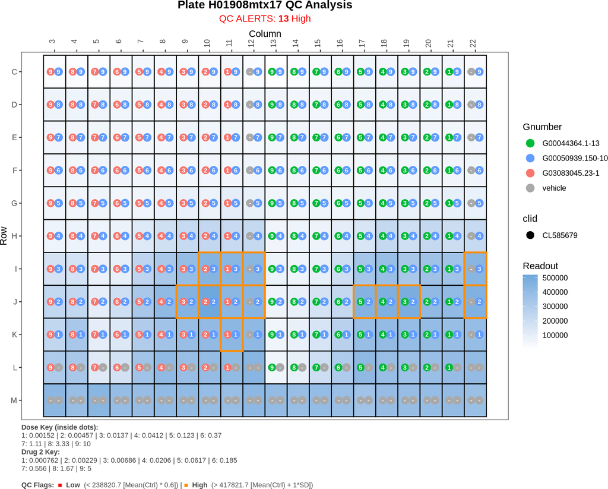

#### 3.4.1.2 E82903mtx17

🔍 Zoom In for Details

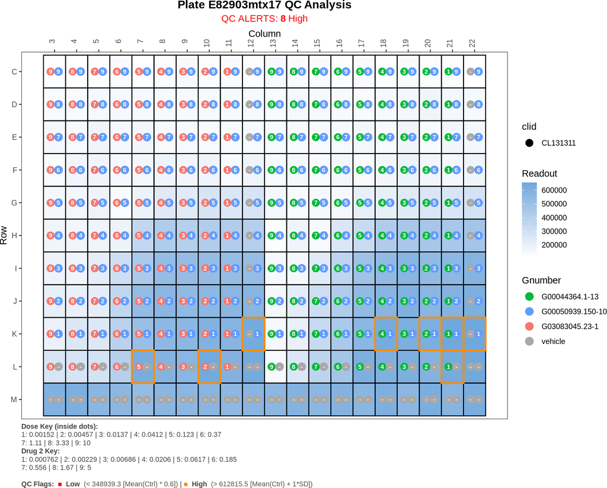

#### 3.4.1.3 E78903mtx17

🔍 Zoom In for Details

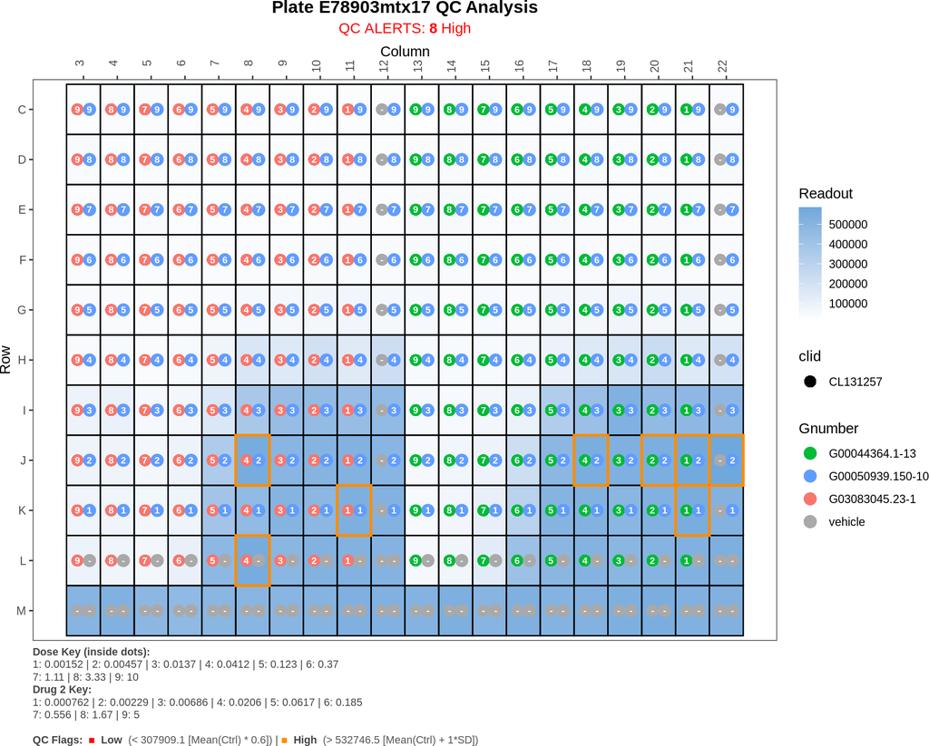

#### 3.4.1.4 H23908mtx17

🔍 Zoom In for Details

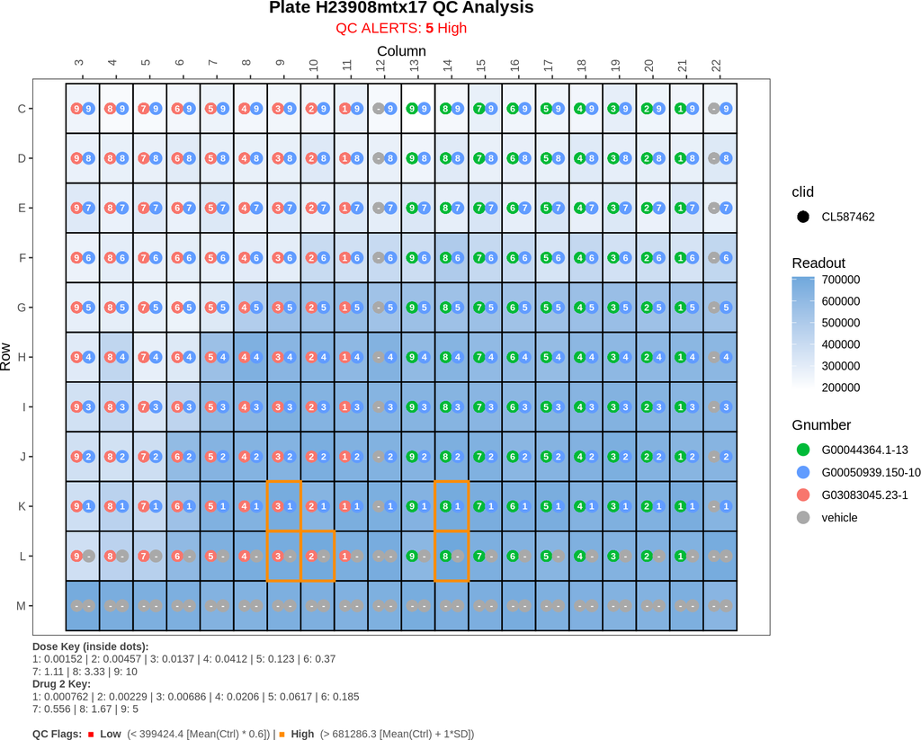

#### 3.4.1.5 E77903mtx17

🔍 Zoom In for Details

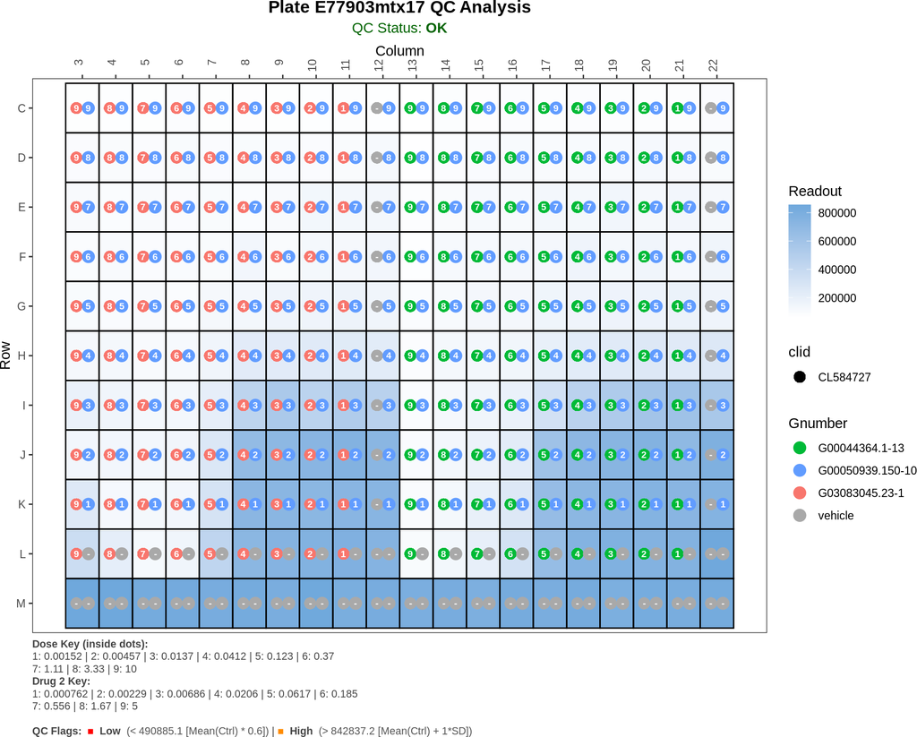

#### 3.4.1.6 E87903mtx17

🔍 Zoom In for Details

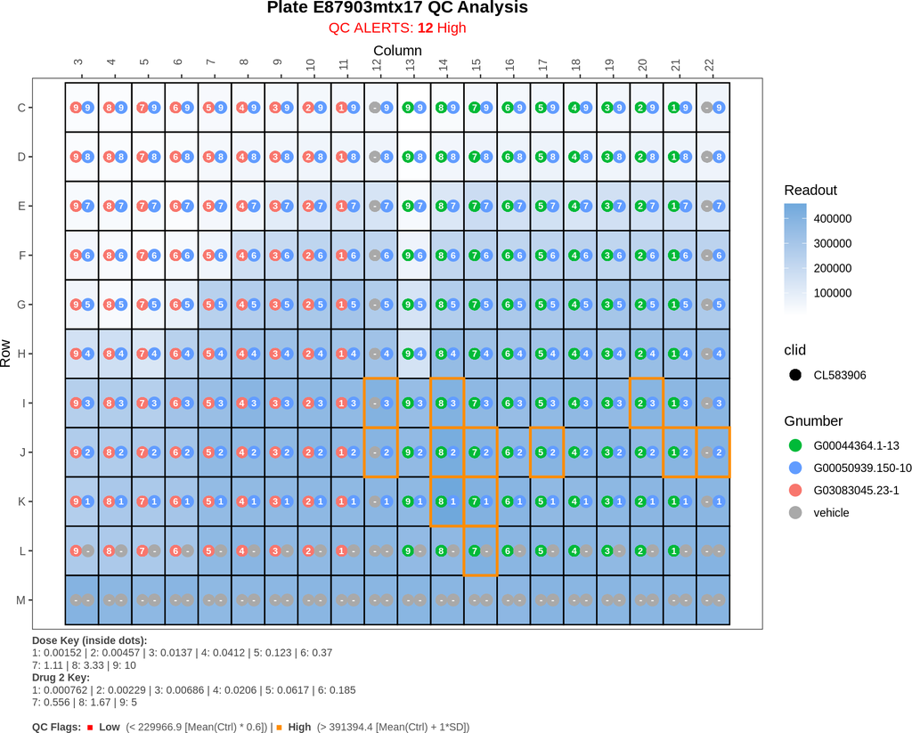

#### 3.4.1.7 H19908mtx17

🔍 Zoom In for Details

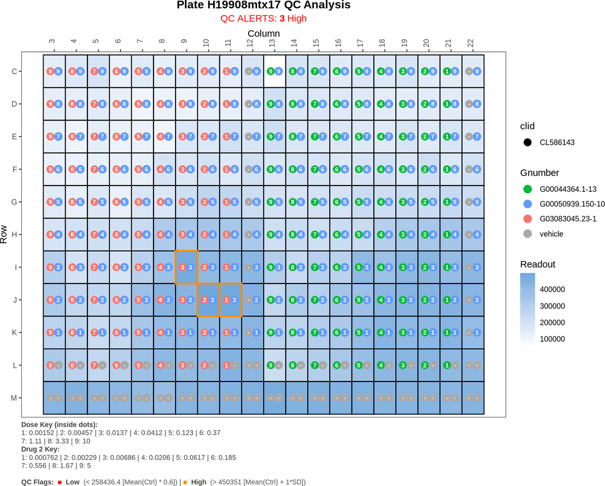

#### 3.4.1.8 E81903mtx17

🔍 Zoom In for Details

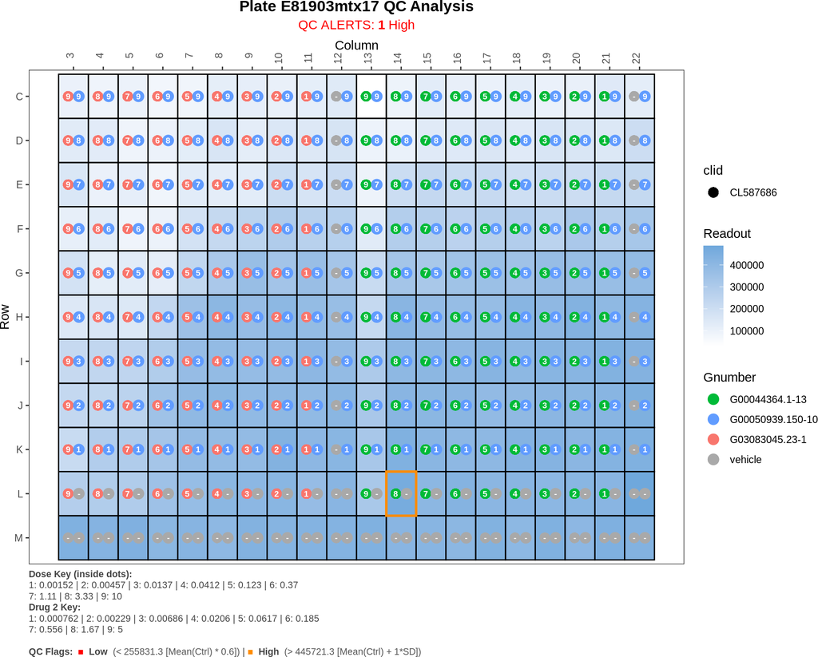

#### 3.4.1.9 K11915mtx17

🔍 Zoom In for Details

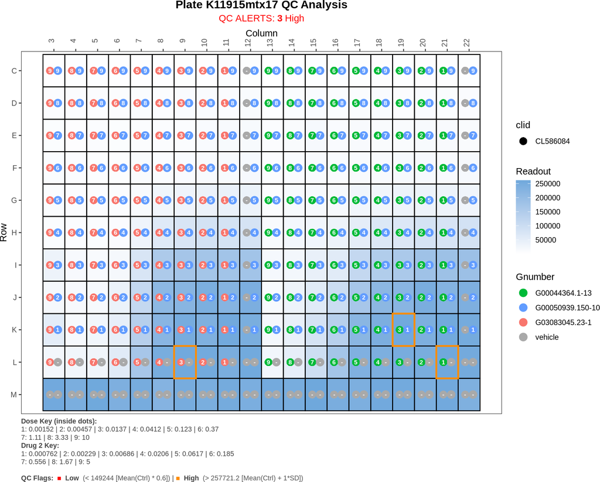

#### 3.4.1.10 K03915mtx17

🔍 Zoom In for Details

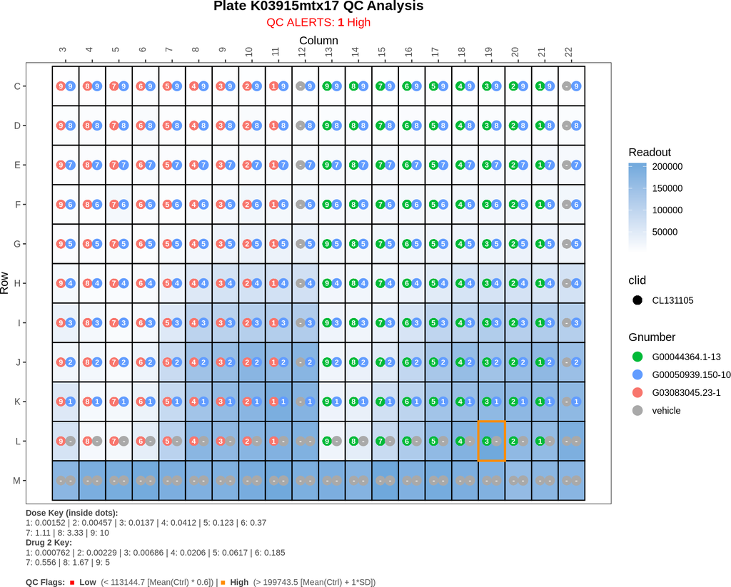

#### 3.4.1.11 K14915mtx17

🔍 Zoom In for Details

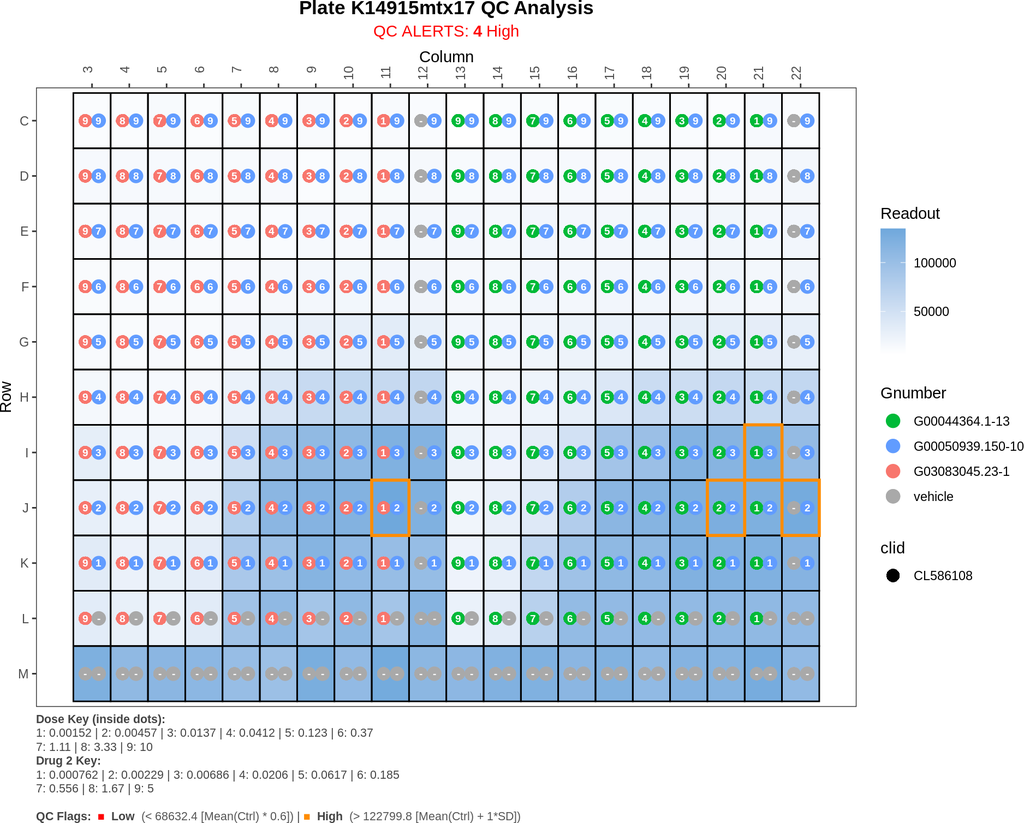

#### 3.4.1.12 K05908mtx17

🔍 Zoom In for Details

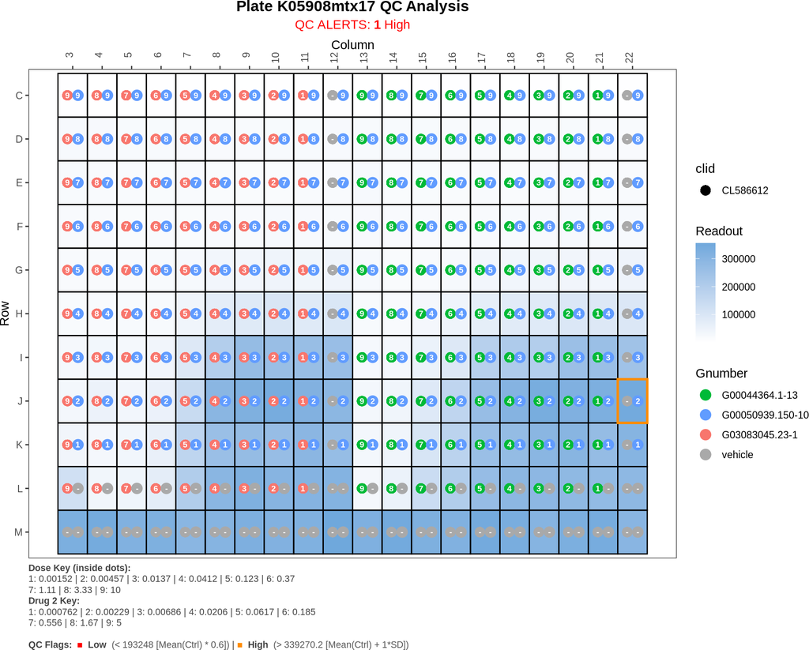

#### 3.4.1.13 E80903mtx17

🔍 Zoom In for Details

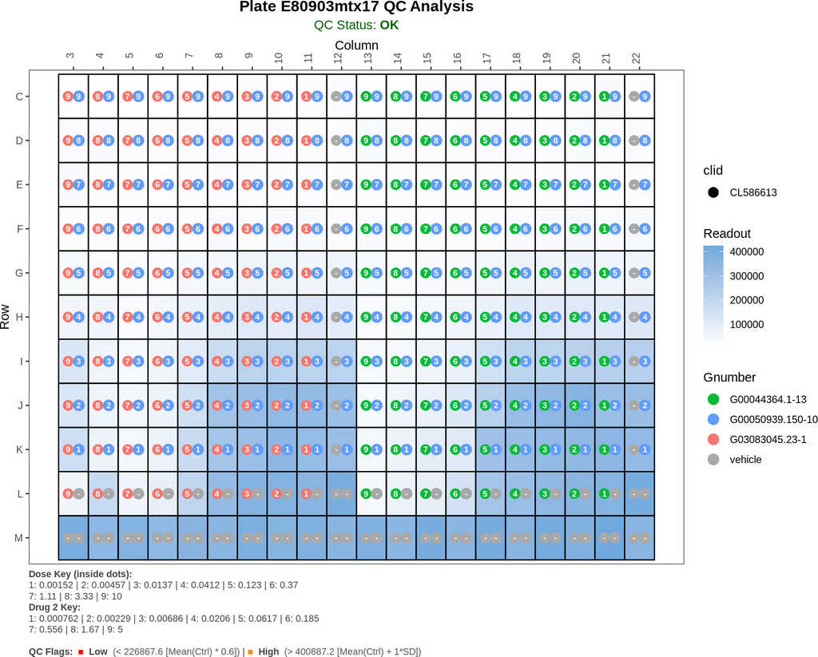

#### 3.4.1.14 E97908mtx17

🔍 Zoom In for Details

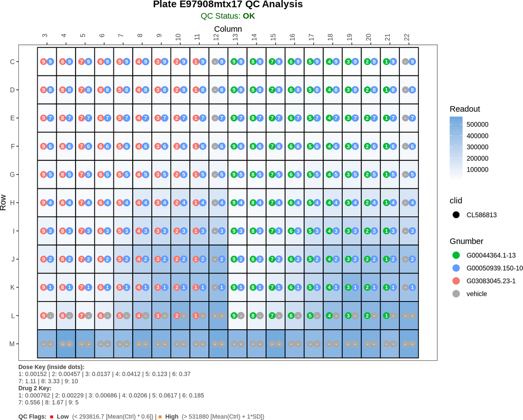

#### 3.4.1.15 E84903mtx17

🔍 Zoom In for Details

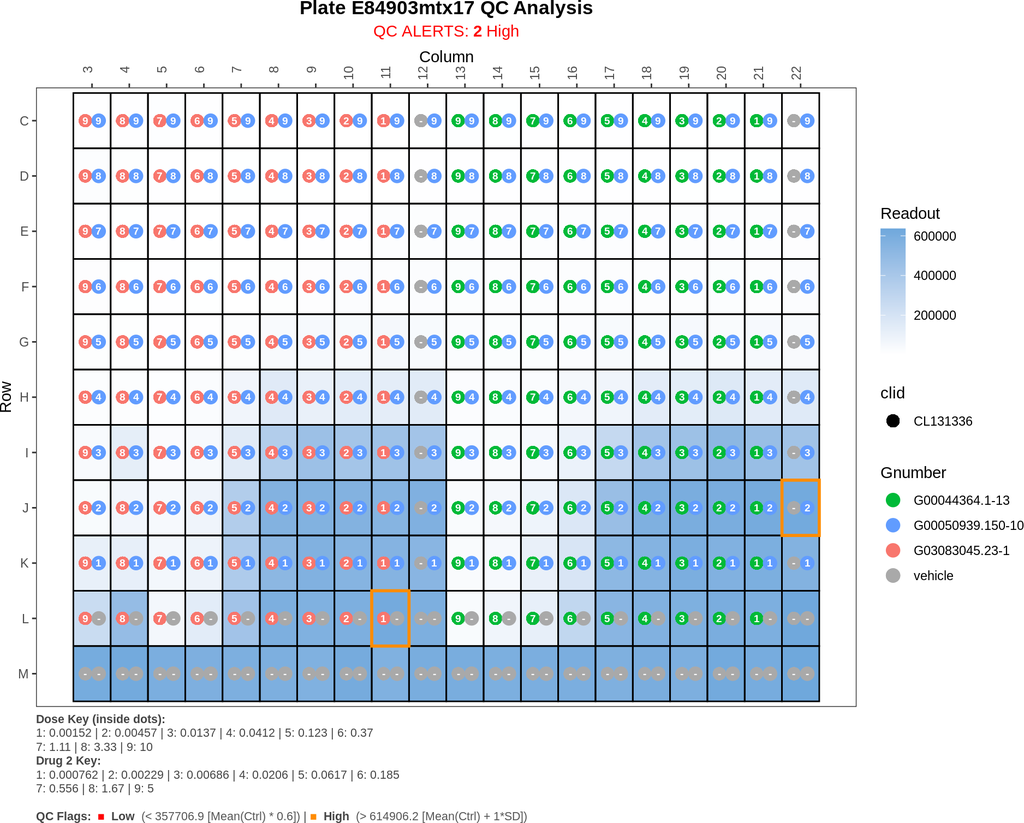

#### 3.4.1.16 E63903mtx17

🔍 Zoom In for Details

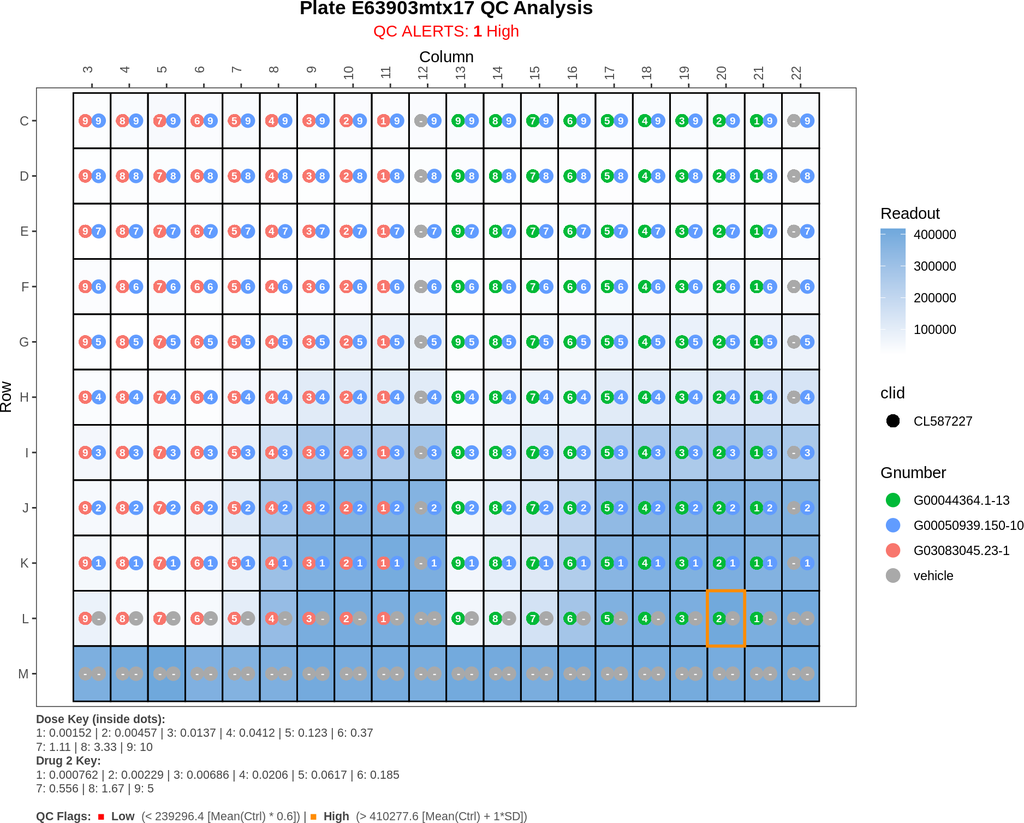

#### 3.4.1.17 E85903mtx17

🔍 Zoom In for Details

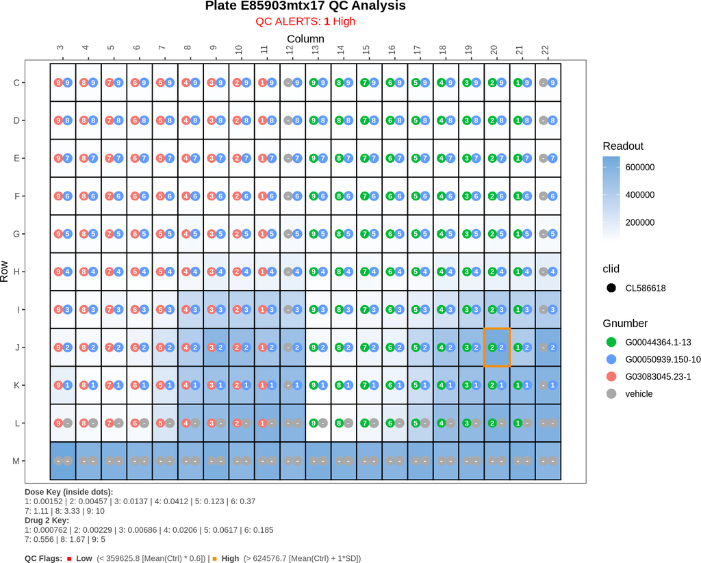

#### 3.4.1.18 H26908mtx17

🔍 Zoom In for Details

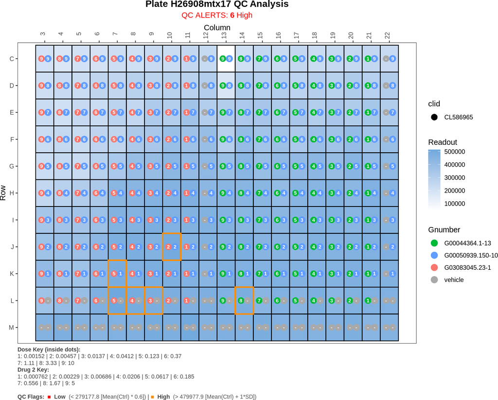

#### 3.4.1.19 H02908mtx17

🔍 Zoom In for Details

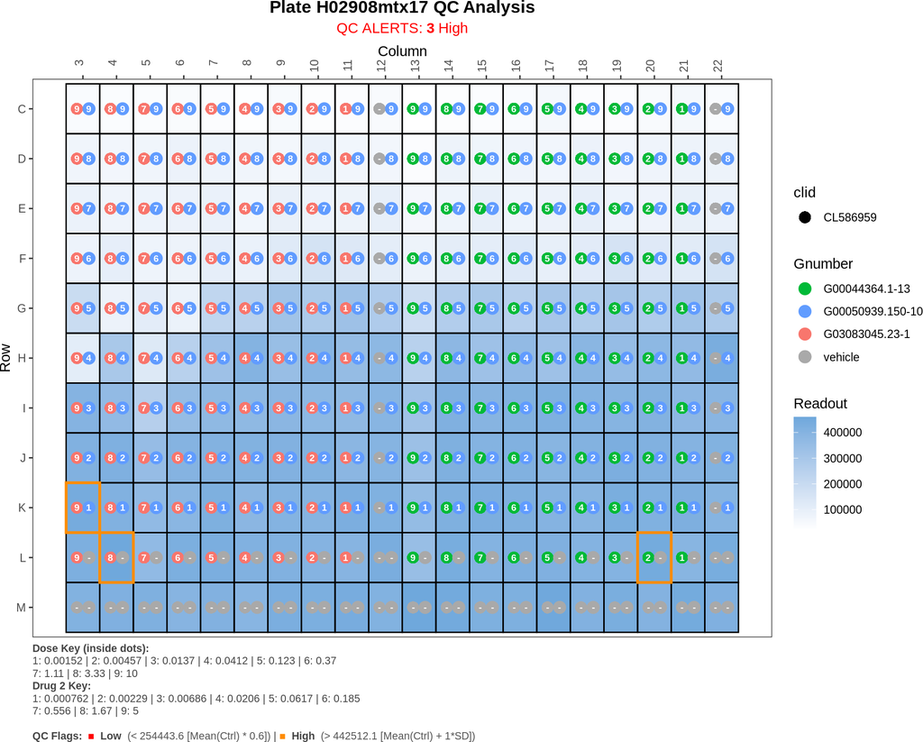

#### 3.4.1.20 H09915mtx17

🔍 Zoom In for Details

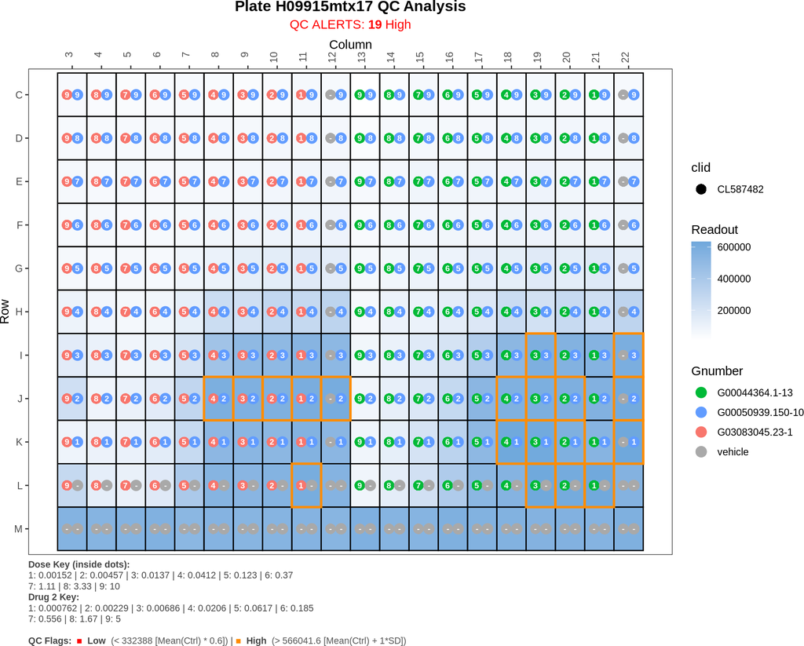

#### 3.4.1.21 E83903mtx17

🔍 Zoom In for Details

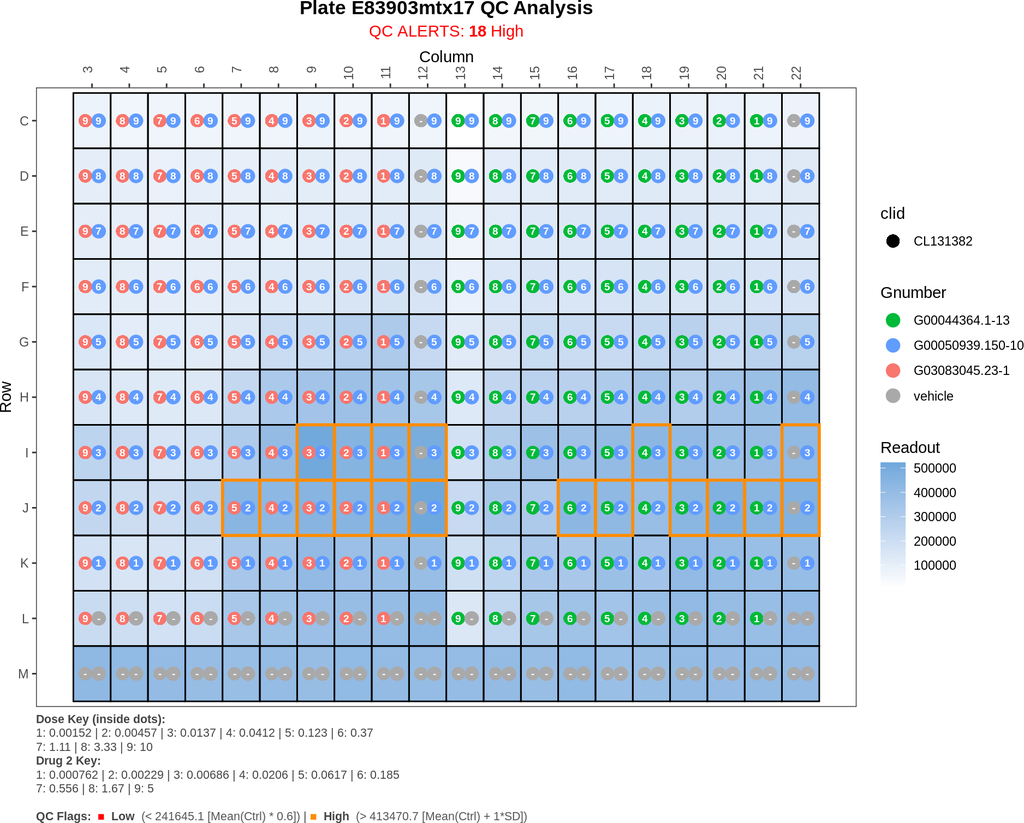

#### 3.4.1.22 E98908mtx17

🔍 Zoom In for Details

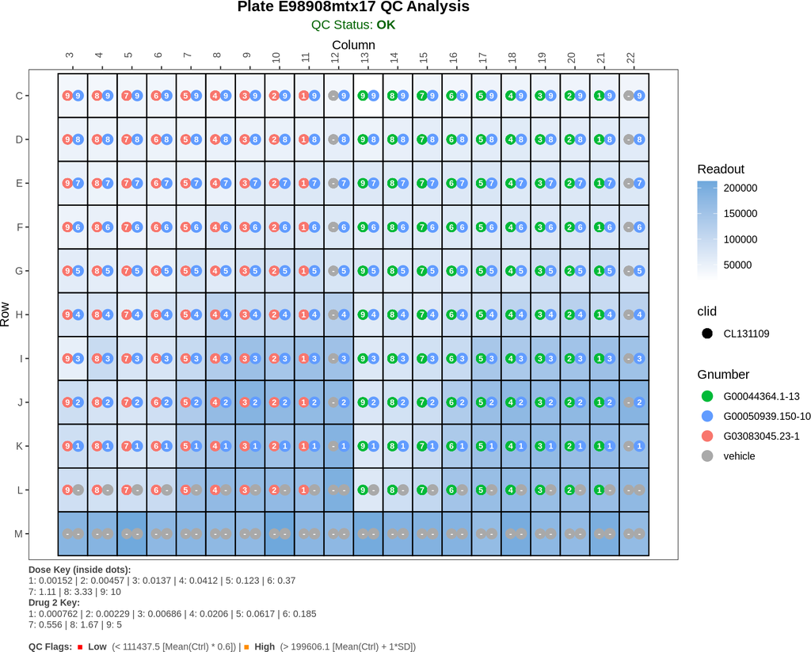

#### 3.4.1.23 E93915mtx17

🔍 Zoom In for Details

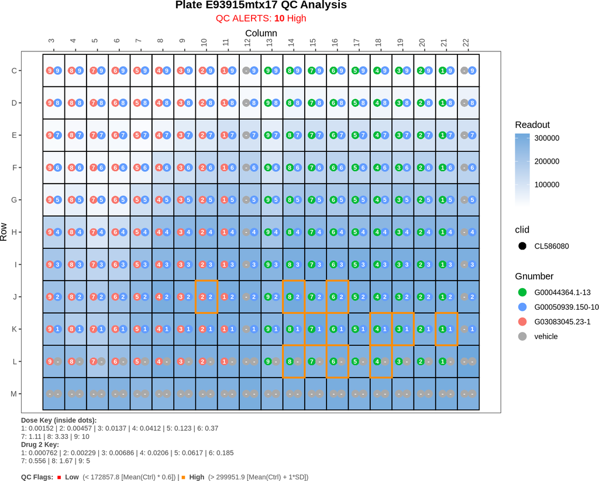

#### 3.4.1.24 E88908mtx17

🔍 Zoom In for Details

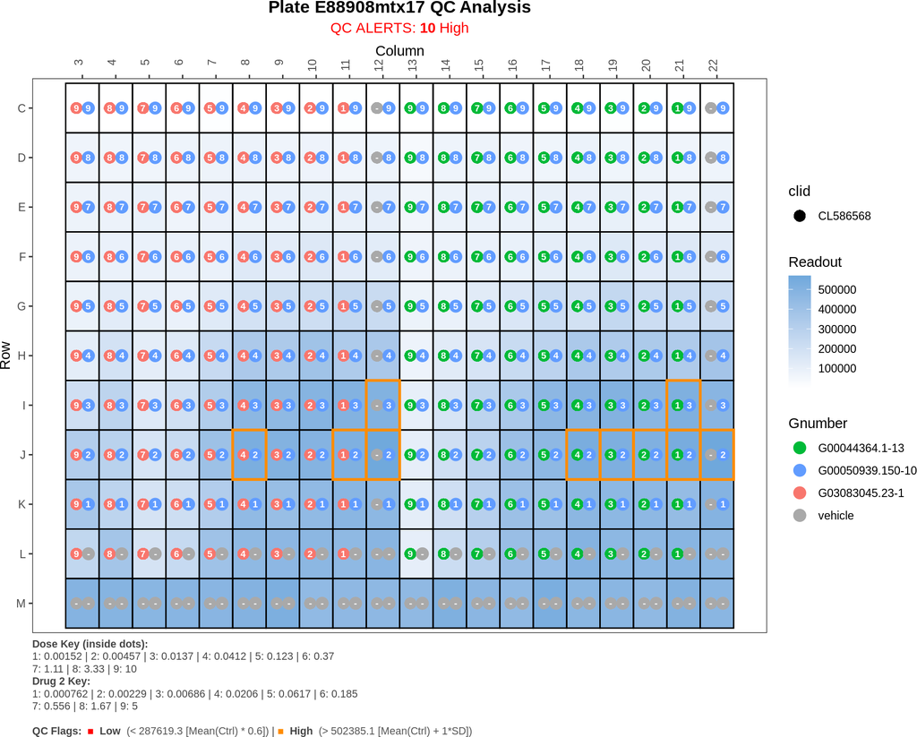

#### 3.4.1.25 K12908mtx17

🔍 Zoom In for Details

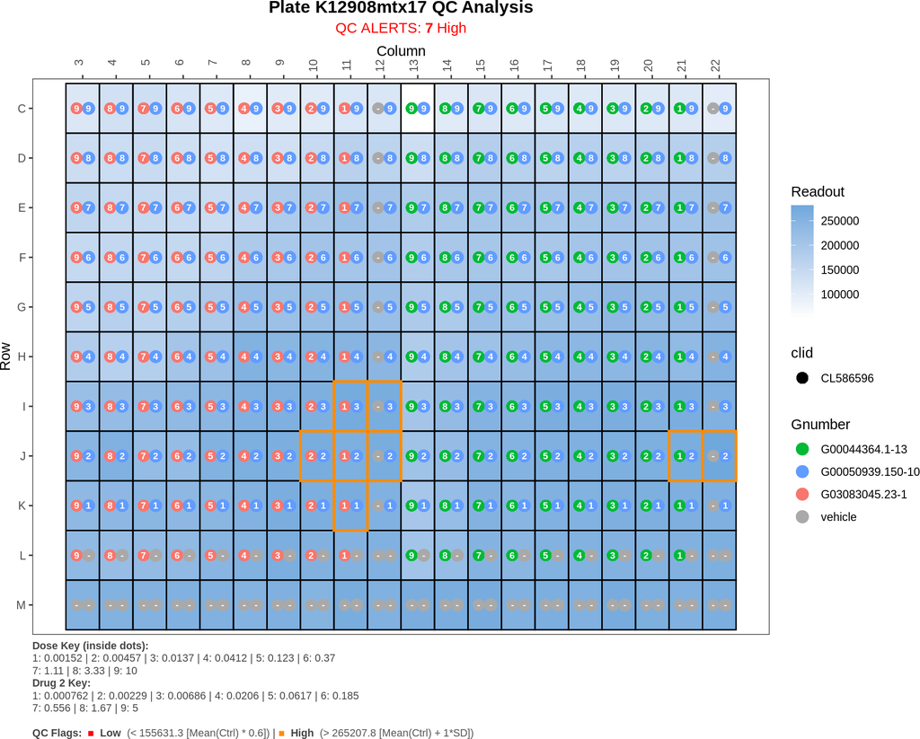

#### 3.4.1.26 E95908mtx17

🔍 Zoom In for Details

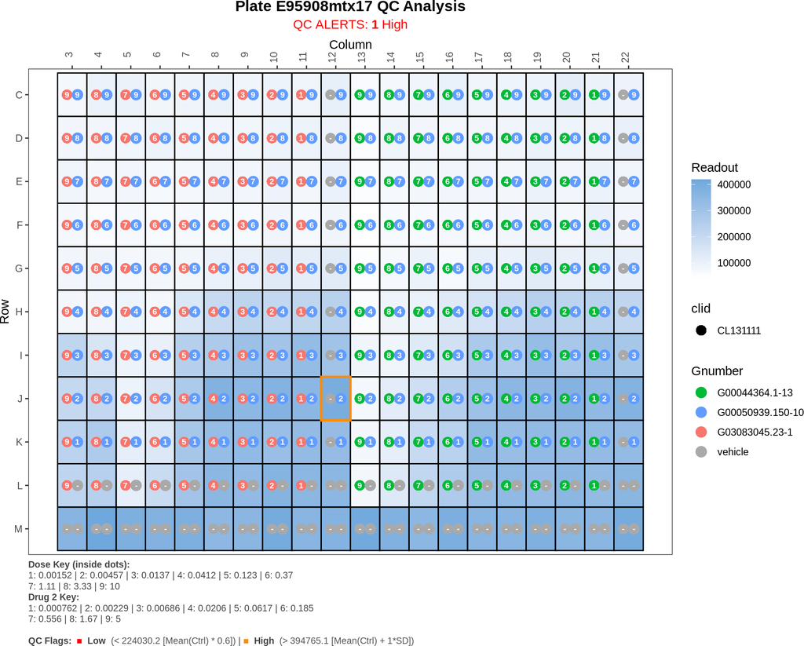

#### 3.4.1.27 E68903mtx17

🔍 Zoom In for Details

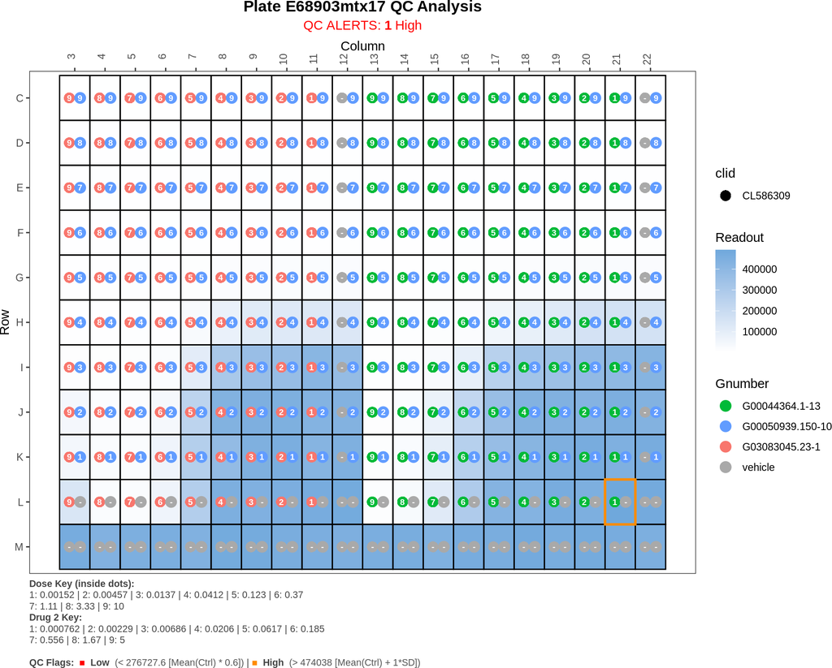

#### 3.4.1.28 E79903mtx17

🔍 Zoom In for Details

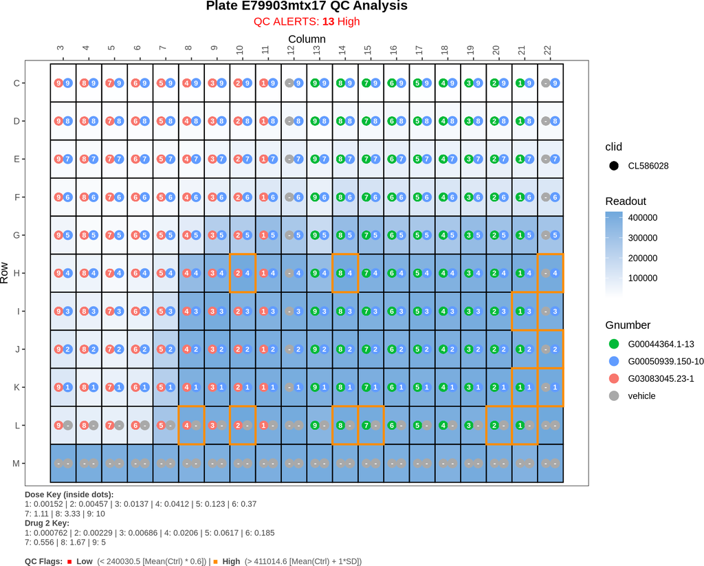

#### 3.4.1.29 K07917mtx17

🔍 Zoom In for Details

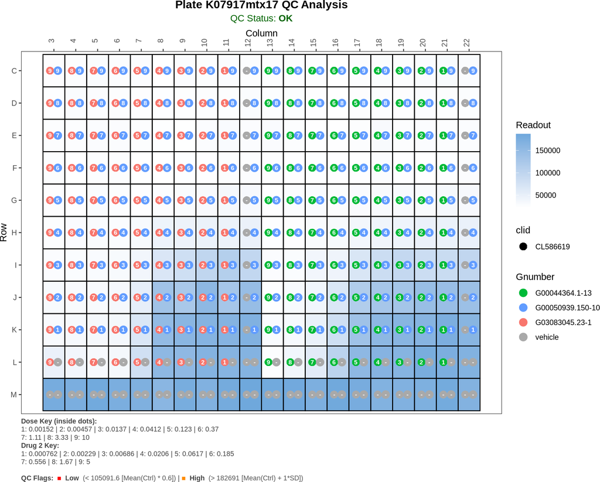

#### 3.4.1.30 K06908mtx17

🔍 Zoom In for Details

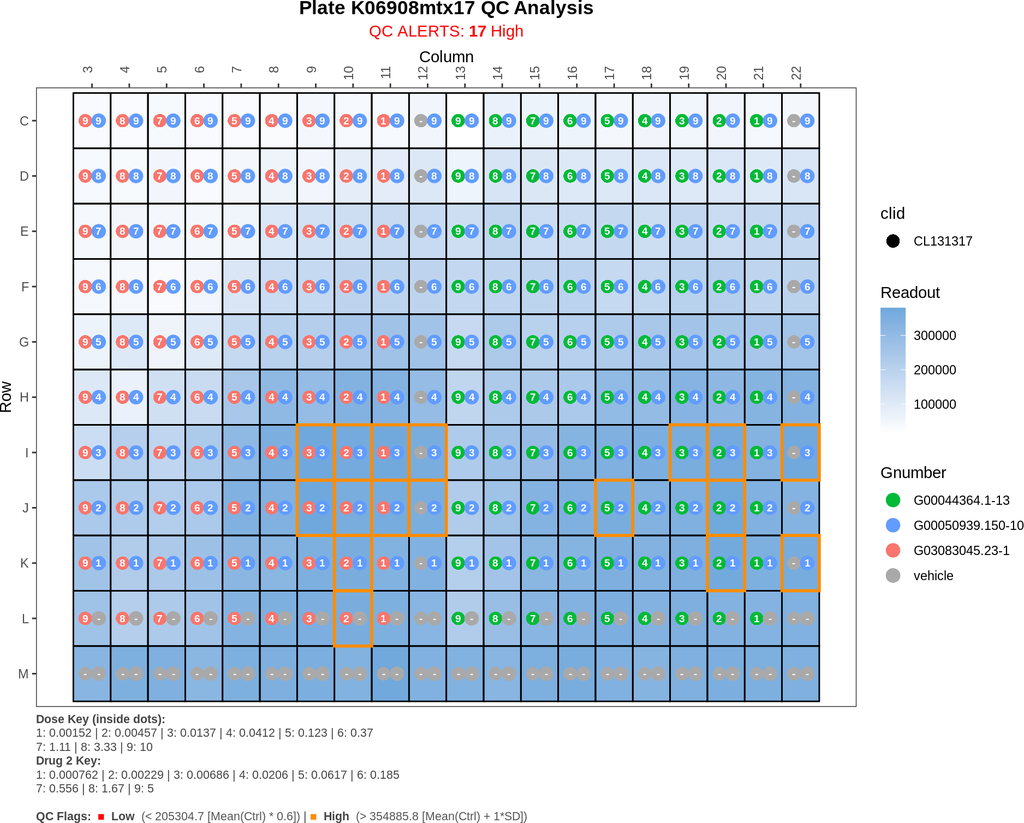

#### 3.4.1.31 H04908mtx17

🔍 Zoom In for Details

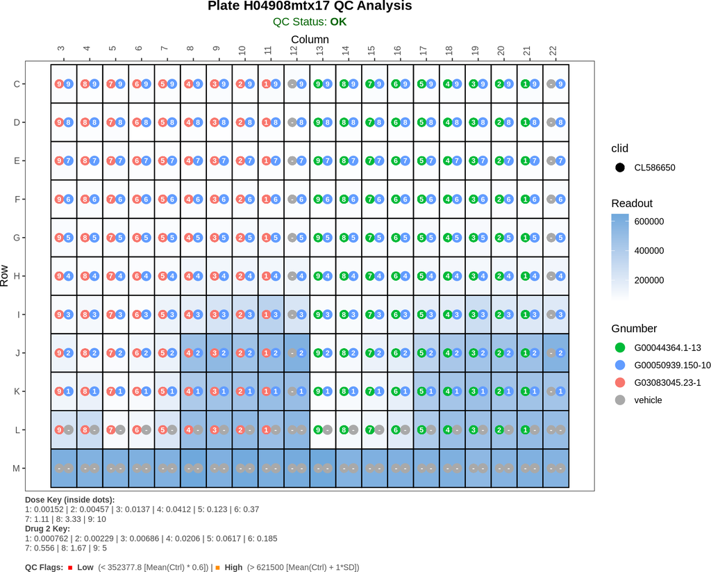